# Using sparklyr with 2013 NYCTaxi Data: Featurization, modeling, and evaluation

Algorithms and Data Science & R Server Teams, Microsoft Data Group

March 09, 2017

# 1 Introduction

This Markdown document shows the use of [sparklyr](http://spark.rstudio.com/index.html) for feature engineering and creating machine learning models. The data used for this exercise is the public NYC Taxi Trip and Fare data-set (2013, December, ~4 Gb, ~13 million rows) available from: http://www.andresmh.com/nyctaxitrips. Data for this exercise can be downloaded from the public blob (see below). The data can be uploaded to the blob (or other storage) attached to your HDInsight cluster (HDFS) and used as input into the scripts shown here.

sparklyr provides bindings to Spark’s distributed machine learning library. In particular, sparklyr allows you to access the machine learning routines provided by the spark.ml package. Together with sparklyr’s dplyr interface, you can easily create and tune machine learning workflows on Spark, orchestrated entirely within R.

Where necessary, small amounts of data is brought to the local data frames for plotting and visualization.

# 2 Creating spark connection, loading packages

```r
###########################################
# LOAD LIBRARIES FROM SPECIFIED PATH
###########################################
Sys.setenv(YARN_CONF_DIR="/opt/hadoop/current/etc/hadoop", HADOOP_HOME="/opt/hadoop/current",
           JAVA_HOME = "/usr/lib/jvm/java-1.8.0-openjdk-1.8.0.111-1.b15.el7_2.x86_64",
           SPARK_HOME = "/dsvm/tools/spark/current",
           PATH=paste0(Sys.getenv("PATH"),":/opt/hadoop/current/bin:/dsvm/tools/spark/current/bin"))
## *** NOTE: SPARK PATH IS DIFFERENT IN DSVM AND HDI CLUSTER

.libPaths(c(file.path(Sys.getenv("SPARK_HOME"), "R", "lib"), .libPaths()))
library(rmarkdown)
library(knitr)
library(sparklyr)
library(dplyr)
library(DBI)
library(gridExtra)
library(ggplot2)

###########################################
## CREATE SPARKLYR SPARK CONNECTION
###########################################
sp <- spark_connect(master = "yarn-client")

###########################################
## SPECIFY BASE HDFS DIRECTORY
###########################################
fullDataDir <- "/user/RevoShare/remoteuser/Data"
## *** NOTE: FILE PATH IS DIFFERENT IN DSVM AND HDI CLUSTER
```

# 3 Read joined trip-fare data and cache in memory

If a data-set is large, it may need to be down-sampled for modeling in reasonable amount of time. Here we used the **sample** function from SparkR to down-sample the joined tax-fare data. We then save the data in HDFS for use as input into the sparklyr modeling functions.

```r
###########################################
# LOAD SAMPLED JOINED TAXI DATA FROM HDFS, CACHE
###########################################
starttime <- Sys.time();

joinedDF <- spark_read_parquet(sp, name = "joined_table",
                               path = file.path(fullDataDir, "NYCjoinedParquetSubset"),
                               memory = TRUE, overwrite = TRUE)
tbl_cache(sp, "joined_table")
head(joinedDF, 3)
```

```
## Source:   query [3 x 9]
## Database: spark connection master=yarn-client app=sparklyr local=FALSE
##
##   payment_type pickup_hour fare_amount tip_amount passenger_count
##          <chr>       <int>       <dbl>      <dbl>           <int>
## 1          CRD          15           8        1.7               1
## 2          CSH          22          14        0.0               1
## 3          CRD           4           7        1.0               4
## # ... with 4 more variables: trip_distance <dbl>, trip_time_in_secs <int>,
## #   TrafficTimeBins <chr>, tipped <int>
```

```r
###########################################
# SHOW THE NUMBER OF OBSERVATIONS IN DATA
###########################################
count(joinedDF)
```

```
## Source:   query [1 x 1]
## Database: spark connection master=yarn-client app=sparklyr local=FALSE
##
##          n
##      <dbl>
## 1 10710669
```

```r
###########################################
# FILTER AND SAMPLE TO A SMALLER DATAFRAME FOR FASTER MODEL BUILDING
###########################################
joinedDFsmall <- joinedDF %>%
            dplyr::filter(trip_distance > 1) %>%
            sdf_sample(fraction = 0.1,
                       replacement = FALSE, seed = 123)

endtime <- Sys.time();
print (endtime - starttime);
```

```
## Time difference of 38.09442 secs
```

# 4 Transform variables using sparklyr functions

```r
###########################################
# CREATE TRANSFORMED FEATURES, BINARIZE PAYMENT-TYPE
###########################################
starttime <- Sys.time();

# Binarizer
joinedDF2 <- joinedDFsmall %>%
  ft_string_indexer(input_col = 'payment_type', output_col = 'payment_ind') %>%
  ft_binarizer(input_col = 'payment_ind', output_col = 'pay_type_bin', threshold = 0.5)

endtime <- Sys.time();
print (endtime - starttime);
```

```
## Time difference of 2.346664 secs
```

# 5 Create train-test partitions

Data can be partitioned into training and testing using the **sdf_partition** function.

```r
starttime <- Sys.time();
###########################################
# CREATE TRAIN/TEST PARTITIONS
###########################################
partitions <- joinedDF2 %>% sdf_partition(training = 0.7, test = 0.3, seed = 123)
head(joinedDF2)
```

```
## Source:   query [6 x 11]
## Database: spark connection master=yarn-client app=sparklyr local=FALSE
##
##   payment_type pickup_hour fare_amount tip_amount passenger_count
##          <chr>       <int>       <dbl>      <dbl>           <int>
## 1          CSH          19        11.0        0.0               1
## 2          CRD          18        10.0        2.5               6
## 3          CSH           9         7.5        0.0               1
## 4          CRD          13        11.0        2.2               1
## 5          CRD           7        13.5        2.0               1
## 6          CRD          18        10.5        2.4               1
## # ... with 6 more variables: trip_distance <dbl>, trip_time_in_secs <int>,
## #   TrafficTimeBins <chr>, tipped <int>, payment_ind <dbl>,
## #   pay_type_bin <dbl>
```

```r
endtime <- Sys.time();
print (endtime - starttime);
```

```
## Time difference of 0.7353468 secs
```

# 6 Create ML models

Spark’s machine learning library can be accessed from sparklyr through the [ml_* family of functions](http://spark.rstudio.com/mllib.html#algorithms). Here we create ML models for the prediction of tip-amount for taxi trips.

## 6.1 CreateElastic Net model

Create elastic net model using training data, and evaluate on test data-set

```r
starttime <- Sys.time();

# Fit elastic net regression model
fit <- partitions$training %>%
          ml_linear_regression(tip_amount ~ pay_type_bin + pickup_hour +
                                 passenger_count + trip_distance +
                                 TrafficTimeBins,
                               alpha = 0.5, lambda = 0.01)

# Show summary of fitted Elastic Net model
summary(fit)
```

```
## Call: ml_linear_regression(., tip_amount ~ pay_type_bin + pickup_hour + passenger_count + trip_distance + TrafficTimeBins, alpha = 0.5, lambda = 0.01)
##
## Deviance Residuals: (approximate):
##       Min        1Q    Median        3Q       Max
## -11.25150  -0.60969   0.08535   0.52259  12.07828
##
## Coefficients:
##            (Intercept)           pay_type_bin            pickup_hour
##            1.794247102           -2.756836660            0.006003461
##        passenger_count          trip_distance TrafficTimeBins_AMRush
##           -0.003104117            0.282365215           -0.056687330
##  TrafficTimeBins_Night TrafficTimeBins_PMRush
##           -0.160170178            0.000000000
##
## R-Squared: 0.6138
## Root Mean Squared Error: 1.391
```

```r
# Predict on test data and keep predictions in Spark context
predictedVals <- sdf_predict(fit, newdata =  partitions$test)
predictedValsSampled <- sdf_sample(predictedVals, fraction = 0.1, replacement = FALSE)
predictedDF <- as.data.frame(predictedValsSampled)

# Evaluate and plot predictions (R-sqr)
Rsqr = cor(predictedDF$tip_amount, predictedDF$prediction)^2; Rsqr;
```

```
## [1] 0.6137143
```

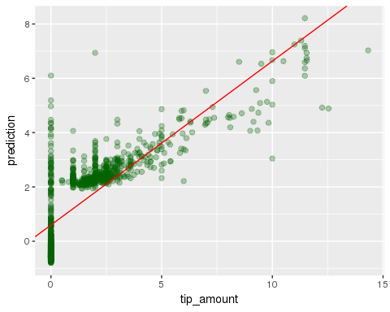

```r
# Sample predictions for plotting
predictedDFSampled <- predictedDF[base::sample(1:nrow(predictedDF), 1000),]

# Plot actual vs. predicted tip amounts
lm_model <- lm(prediction ~ tip_amount, data = predictedDFSampled)
ggplot(predictedDFSampled, aes(tip_amount, prediction)) +
  geom_point(col='darkgreen', alpha=0.3, pch=19, cex=2) +
  geom_abline(aes(slope = summary(lm_model)$coefficients[2,1],
                  intercept = summary(lm_model)$coefficients[1,1]),
              color = "red")
```

```r
endtime <- Sys.time();
print (endtime - starttime);
```

```
## Time difference of 39.43061 secs
```

## 6.2 Create Random Forest Model

Create a random forest model using training data, and evaluate on test data-set

```r
starttime <- Sys.time();

# Fit Random Forest regression model
fit <- partitions$training %>%
          ml_random_forest(response = "tip_amount",
                           features = c("pay_type_bin", "fare_amount", "pickup_hour",
                                        "passenger_count",  "trip_distance",
                                        "TrafficTimeBins"),
                           max.bins = 32L, max.depth = 5L, num.trees = 25L)

# Show summary of fitted Random Forest model
summary(fit)
```

```
##                             Length Class      Mode
## features                     8     -none-     character
## response                     1     -none-     character
## max.bins                     1     -none-     numeric
## max.depth                    1     -none-     numeric
## num.trees                    1     -none-     numeric
## feature.importances          8     -none-     numeric
## trees                       25     -none-     list
## data                         2     spark_jobj environment
## ml.options                   6     ml_options list
## categorical.transformations  1     -none-     environment
## model.parameters             5     -none-     list
## .call                        7     -none-     call
## .model                       2     spark_jobj environment
```

```r
# Get feature importance of RF model
feature_importance <- ml_tree_feature_importance(sp, fit) %>%
    mutate(importance = as.numeric(levels(importance))[importance]) %>%
    mutate(feature = as.character(feature));

plot1 <- feature_importance %>%
  ggplot(aes(reorder(feature, importance), importance)) +
  geom_bar(stat = "identity", fill='darkgreen') + coord_flip() + xlab("") +
  ggtitle("Feature Importance")


# Predict on test data and keep predictions in Spark context
predictedVals <- sdf_predict(fit, newdata =  partitions$test)
predictedValsSampled <- sdf_sample(predictedVals, fraction = 0.1, replacement = FALSE)
predictedDF <- as.data.frame(predictedValsSampled)

# Evaluate and plot predictions (R-sqr)
Rsqr = cor(predictedDF$tip_amount, predictedDF$prediction)^2; Rsqr;
```

```
## [1] 0.7731771
```

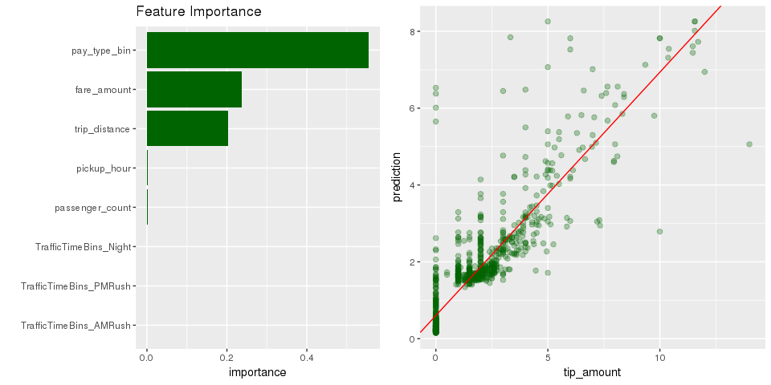

```r
# Sample predictions for plotting
predictedDFSampled <- predictedDF[base::sample(1:nrow(predictedDF), 1000),]

# Plot
lm_model <- lm(prediction ~ tip_amount, data = predictedDFSampled)
plot2 <- ggplot(predictedDFSampled, aes(tip_amount, prediction)) +
  geom_point(col='darkgreen', alpha=0.3, pch=19, cex=2) +
  geom_abline(aes(slope = summary(lm_model)$coefficients[2,1],
                  intercept = summary(lm_model)$coefficients[1,1]),
              color = "red")

grid.arrange(plot1, plot2, ncol=2)
```

```r
endtime <- Sys.time();
print (endtime - starttime);
```

```
## Time difference of 48.3148 secs
```

## 6.3 Create Gradient Boosted Tree Model

Create a gradient boosted tree model using training data, and evaluate on test data-set

```r
starttime <- Sys.time();

# Fit Gradient Boosted Tree regression model
fit <- partitions$training %>%
        ml_gradient_boosted_trees(tip_amount ~ pay_type_bin + pickup_hour +
                                    passenger_count + trip_distance +
                                    TrafficTimeBins,
                                  max.bins = 32L, max.depth = 5L,
                                  type = "regression")

# Show summary of fitted Random Forest model
summary(fit)
```

```
##                             Length Class      Mode
## features                     7     -none-     character
## response                     1     -none-     character
## max.bins                     1     -none-     numeric
## max.depth                    1     -none-     numeric
## trees                       20     -none-     list
## data                         2     spark_jobj environment
## ml.options                   6     ml_options list
## categorical.transformations  1     -none-     environment
## model.parameters             5     -none-     list
## .call                        6     -none-     call
## .model                       2     spark_jobj environment
```

```r
# Get feature importance of GBT model
feature_importance <- ml_tree_feature_importance(sp, fit) %>%
    mutate(importance = as.numeric(levels(importance))[importance]) %>%
    mutate(feature = as.character(feature));

plot1 <- feature_importance %>%
  ggplot(aes(reorder(feature, importance), importance)) +
  geom_bar(stat = "identity", fill='darkgreen') + coord_flip() + xlab("") +
  ggtitle("Feature Importance")

# Predict on test data and keep predictions in Spark context
predictedVals <- sdf_predict(fit, newdata =  partitions$test)
predictedValsSampled <- sdf_sample(predictedVals, fraction = 0.1, replacement = FALSE)
predictedDF <- as.data.frame(predictedValsSampled)

# Evaluate and plot predictions (R-sqr)
Rsqr = cor(predictedDF$tip_amount, predictedDF$prediction)^2; Rsqr;
```

```
## [1] 0.7606691
```

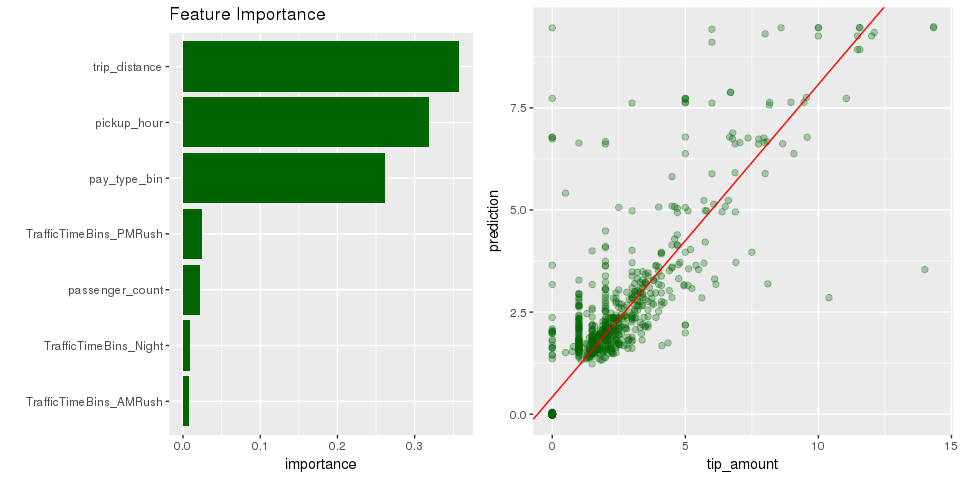

```r
# Sample predictions for plotting
predictedDFSampled <- predictedDF[base::sample(1:nrow(predictedDF), 1000),]

# Plot
lm_model <- lm(prediction ~ tip_amount, data = predictedDFSampled)
plot2 <- ggplot(predictedDFSampled, aes(tip_amount, prediction)) +
  geom_point(col='darkgreen', alpha=0.3, pch=19, cex=2) +
  geom_abline(aes(slope = summary(lm_model)$coefficients[2,1],
                  intercept = summary(lm_model)$coefficients[1,1]),
              color = "red")

grid.arrange(plot1, plot2, ncol=2)
```

```r
endtime <- Sys.time();
print (endtime - starttime);
```

```
## Time difference of 1.078493 mins
```

# 7 Uncache objects and disconnect from spark

```r
###########################################
# UNCACHE TABLES
###########################################
tbl_uncache(sp, "joined_table")

###########################################
# DISCONNECT SPARK CONNECTION
###########################################
spark_disconnect(sp)
```

# 8 Summary

The examples shown here can be adopted to fit other data exploration and modeling scenarios having different data-types or prediction tasks (e.g. classification)